# Hypothesis Figures

Allysa

2022-12-05

## Exploratory Analysis: Hypotheses

Open the tidyverse and dplyr libraries to use for data analysis. Also open up the data file by reading in the .csv. Removed unwanted data columns to clean the data.

```r
library(tidyverse)
library(dplyr)
library(wesanderson)
# Quick display of two cabapilities of GGally, to assess the distribution and correlation of variables
library(GGally)
data <- read.csv(file = '/stor/home/ard3696/data/ai4i2020.csv')
data_clean <- data %>% select(-UDI, - Product.ID)
head(data_clean)
```

```
##   Type Air.temperature..K. Process.temperature..K. Rotational.speed..rpm.
## 1    M               298.1                   308.6                   1551
## 2    L               298.2                   308.7                   1408
## 3    L               298.1                   308.5                   1498
## 4    L               298.2                   308.6                   1433
## 5    L               298.2                   308.7                   1408
## 6    M               298.1                   308.6                   1425
##   Torque..Nm. Tool.wear..min. Machine.failure TWF HDF PWF OSF RNF
## 1        42.8               0               0   0   0   0   0   0
## 2        46.3               3               0   0   0   0   0   0
## 3        49.4               5               0   0   0   0   0   0
## 4        39.5               7               0   0   0   0   0   0
## 5        40.0               9               0   0   0   0   0   0
## 6        41.9              11               0   0   0   0   0   0
```

Remove additional columns that are not necessary for this portion of the data analysis. This inclues variables such as rotational speed, tool wear, air temperature, process temperature, and torque. The group by the type of failure and select all of the failures that are reported to occur, 1 = failure, 0 = no failure.

```r
data_clean %>%
  select(-Rotational.speed..rpm.,
         -Tool.wear..min.,
         -Air.temperature..K.,
         -Process.temperature..K.,
         -Torque..Nm.) %>%
  group_by(Type) %>%
  filter(TWF == 1 | HDF == 1 | PWF == 1 | OSF == 1 | RNF == 1 )
```

```
## # A tibble: 348 × 7
## # Groups:   Type [3]
##    Type  Machine.failure   TWF   HDF   PWF   OSF   RNF
##    <chr>           <int> <int> <int> <int> <int> <int>
##  1 L                   1     0     0     1     0     0
##  2 L                   1     0     0     1     1     0
##  3 L                   1     1     0     0     0     0
##  4 L                   1     0     0     0     1     0
##  5 L                   1     0     0     0     1     0
##  6 L                   1     0     0     1     0     0
##  7 M                   1     0     0     1     0     0
##  8 M                   1     0     0     1     0     0
##  9 L                   1     0     0     0     1     0
## 10 L                   1     0     0     0     1     0
## # … with 338 more rows
```

Hypothesis 1 Our first hypothesis focuses on determining if HDF is the most common failure type. Here provides a visualization of the probability of a failure to occur, sorted by each failure type. First, we have to select all of the failure types, summarize the average of the failure of occurring, tidy the dataset, the mutate the values to represent a percentage. Then we chain the ggplot function to produce the barplot.

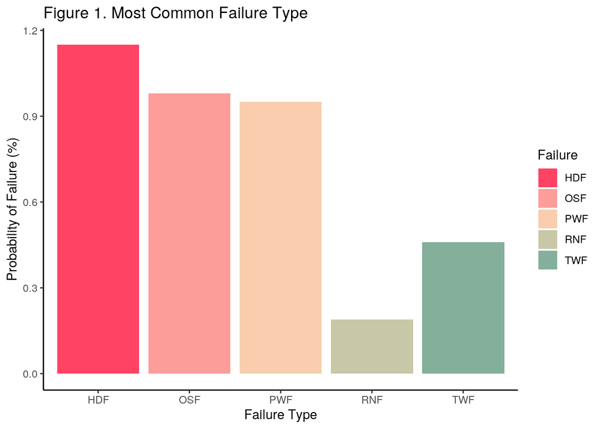

```r
data_clean %>%
  select(TWF, HDF, PWF, OSF, RNF) %>%
  summarize_all(mean) %>%
  pivot_longer(everything()) %>%
  mutate(value = value*100) %>%
  ggplot()+
  geom_bar(aes(name, value, fill = name), stat='identity') +
  xlab("Failure Type") + ylab("Probability of Failure (%)") +
  scale_fill_manual(values = c('#FE4365', '#FC9D9A', '#F9CDAD', '#C8C8A9', '#83AF9B'), name = "Failure") +
  ggtitle('Figure 1. Most Common Failure Type') + theme_classic()
```

Hypothesis 2 For our second hypothesis we focused on the quality of products associated with the occurrence of failures. We have to sort the data relative to failure type and orgainze by low, medium, and high quality products.

```r
data_clean$Type <- factor(data_clean$Type, levels = c('L', 'M', 'H'))
data_clean <- data_clean %>% mutate(NumFails = TWF + HDF + PWF + OSF + RNF)
head(data_clean)
```

```
##   Type Air.temperature..K. Process.temperature..K. Rotational.speed..rpm.
## 1    M               298.1                   308.6                   1551
## 2    L               298.2                   308.7                   1408
## 3    L               298.1                   308.5                   1498
## 4    L               298.2                   308.6                   1433
## 5    L               298.2                   308.7                   1408
## 6    M               298.1                   308.6                   1425
##   Torque..Nm. Tool.wear..min. Machine.failure TWF HDF PWF OSF RNF NumFails
## 1        42.8               0               0   0   0   0   0   0        0
## 2        46.3               3               0   0   0   0   0   0        0
## 3        49.4               5               0   0   0   0   0   0        0
## 4        39.5               7               0   0   0   0   0   0        0
## 5        40.0               9               0   0   0   0   0   0        0
## 6        41.9              11               0   0   0   0   0   0        0
```

We then had to chain to the data_clean file to determine when there was a failure to how many occurred the the quality of the product type that was associated that value. We also added a new column that included the proportion of that failure to occur.

```r
data_clean %>% filter(NumFails > 0) %>% select(Type, NumFails) %>% group_by(Type, NumFails) %>% summarize(n = n()) %>% mutate(prop = n/sum(n) * 100)
```

```
## # A tibble: 6 × 4
## # Groups:   Type [3]
##   Type  NumFails     n  prop
##   <fct>    <int> <int> <dbl>
## 1 L            1   226 93.0
## 2 L            2    17  7.00
## 3 M            1    75 92.6
## 4 M            2     6  7.41
## 5 H            1    23 95.8
## 6 H            3     1  4.17
```

Plot the figure that reveals the count of the failures to occur relative to the quality type.

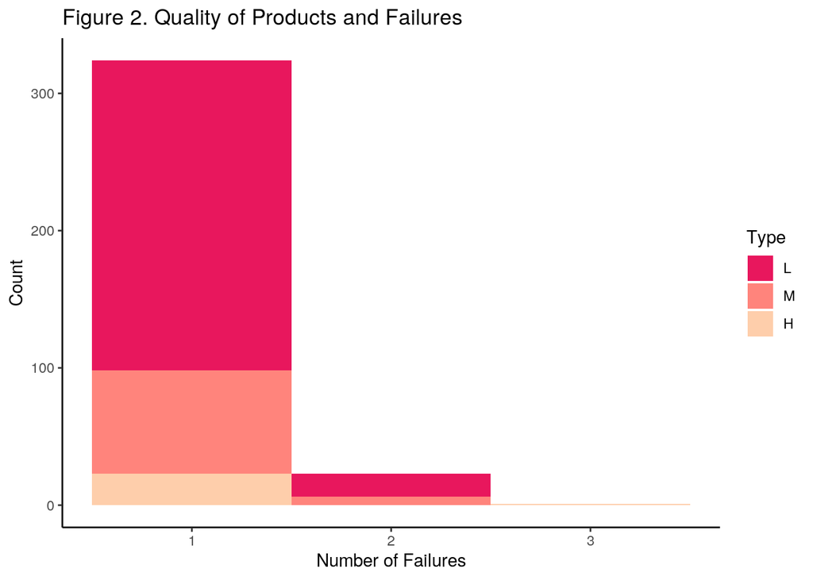

```r
data_clean %>% filter(NumFails > 0) %>% ggplot(aes(x=NumFails, fill=Type)) + geom_histogram(bins = 3) +
theme(legend.position=c(.8,.8), legend.direction = "horizontal") + xlab('Number of Failures') + ylab('Count')+ theme_classic() + scale_fill_manual(values = c("#E8175D", "#FF847C", '#FECEAB')) + ggtitle('Figure 2. Quality of Products and Failures')
```

Plot the proportion of each level of failures relative to the low, medium, and high quality types. The data had to be cleaned to carry out this analysis and is provided in this block of code.

Number of Failures: 1

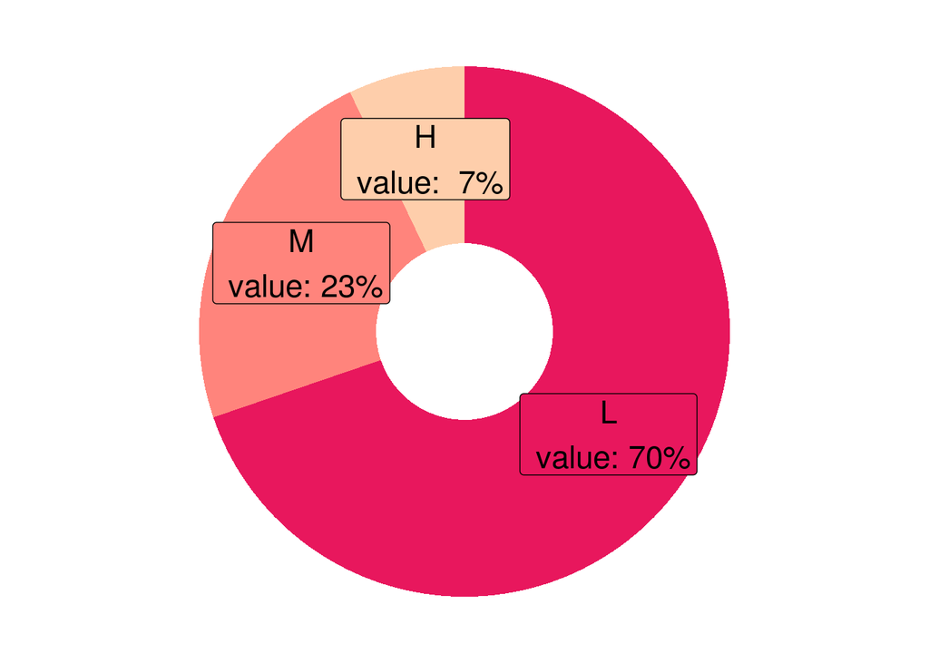

```r
data_NumFails1 <- data_clean %>% filter(NumFails == 1) %>% select(Type, NumFails) %>% group_by(Type) %>% summarize(count = n())
data_NumFails1$fraction = data_NumFails1$fraction = data_NumFails1$count / sum(data_NumFails1$count)
data_NumFails1$ymax = cumsum(data_NumFails1$fraction)
data_NumFails1$ymin = c(0, head(data_NumFails1$ymax, n=-1))

# Compute label position
data_NumFails1$labelPosition <- (data_NumFails1$ymax + data_NumFails1$ymin) / 2

# Compute a good label
data_NumFails1$label <- paste0(data_NumFails1$Type, "\n value: ", format(round(data_NumFails1$fraction*100, 0), nsmall = 0), "%")

# Make the plot
ggplot(data_NumFails1, aes(ymax=ymax, ymin=ymin, xmax=4, xmin=3, fill=Type)) +
  geom_rect() +
  geom_label( x=3.5, aes(y=labelPosition, label=label), size=6) +
  coord_polar(theta="y") +
  xlim(c(2.5, 4)) +
  theme_void() +
  theme(legend.position = "none") + scale_fill_manual(values = c("#E8175D", "#FF847C", '#FECEAB'))
```

Number of Failures: 2

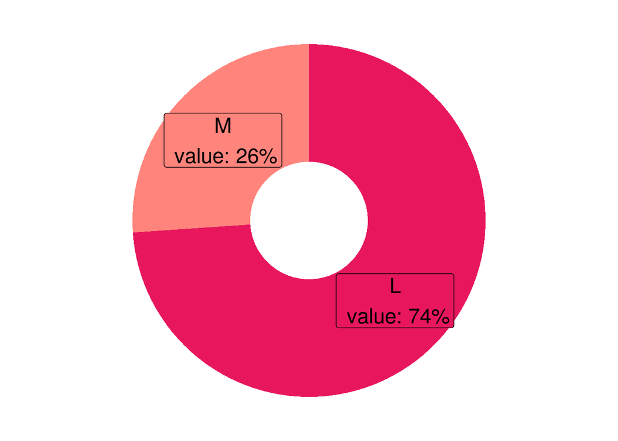

```r
data_NumFails1 <- data_clean %>% filter(NumFails == 2) %>% select(Type, NumFails) %>% group_by(Type) %>% summarize(count = n())
data_NumFails1$fraction = data_NumFails1$fraction = data_NumFails1$count / sum(data_NumFails1$count)
data_NumFails1$ymax = cumsum(data_NumFails1$fraction)
data_NumFails1$ymin = c(0, head(data_NumFails1$ymax, n=-1))

# Compute label position
data_NumFails1$labelPosition <- (data_NumFails1$ymax + data_NumFails1$ymin) / 2

# Compute a good label
data_NumFails1$label <- paste0(data_NumFails1$Type, "\n value: ", format(round(data_NumFails1$fraction*100, 0), nsmall = 0), "%")

# Make the plot
ggplot(data_NumFails1, aes(ymax=ymax, ymin=ymin, xmax=4, xmin=3, fill=Type)) +
  geom_rect() +
  geom_label( x=3.5, aes(y=labelPosition, label=label), size=6) +
  coord_polar(theta="y") +
  xlim(c(2.5, 4)) +
  theme_void() +
  theme(legend.position = "none") + scale_fill_manual(values = c("#E8175D", "#FF847C", '#FECEAB'))
```

Number of Failures: 3

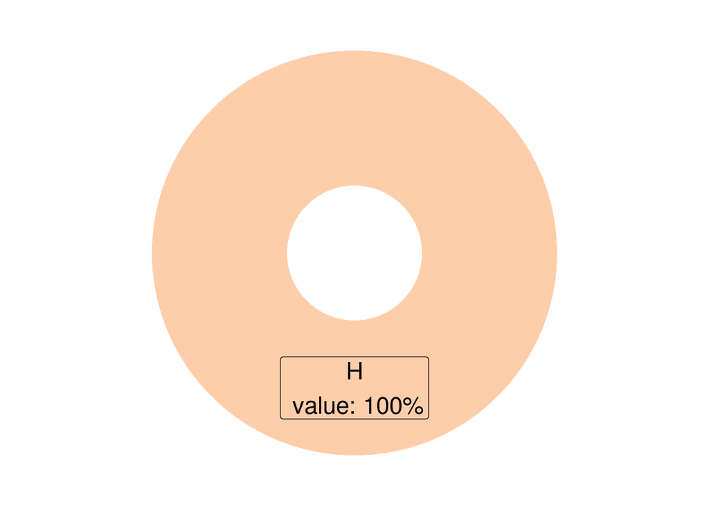

```r
data_NumFails1 <- data_clean %>% filter(NumFails == 3) %>% select(Type, NumFails) %>% group_by(Type) %>% summarize(count = n())
data_NumFails1$fraction = data_NumFails1$fraction = data_NumFails1$count / sum(data_NumFails1$count)
data_NumFails1$ymax = cumsum(data_NumFails1$fraction)
data_NumFails1$ymin = c(0, head(data_NumFails1$ymax, n=-1))

# Compute label position
data_NumFails1$labelPosition <- (data_NumFails1$ymax + data_NumFails1$ymin) / 2

# Compute a good label
data_NumFails1$label <- paste0(data_NumFails1$Type, "\n value: ", format(round(data_NumFails1$fraction*100, 0), nsmall = 0), "%")

# Make the plot
ggplot(data_NumFails1, aes(ymax=ymax, ymin=ymin, xmax=4, xmin=3, fill=Type)) +
  geom_rect() +
  geom_label( x=3.5, aes(y=labelPosition, label=label), size=6) +
  coord_polar(theta="y") +
  xlim(c(2.5, 4)) +
  theme_void() +
  theme(legend.position = "none") + scale_fill_manual(values = c('#FECEAB', "#FF847C", '#FECEAB'))
```

Hypothesis 3

For this portion of the exploratory analysis we hypothesized that some features of the production process would have a high correlation compared to others. We had to clean the dataset to include a new column for temperature difference.

```r
data_clean <- data_clean %>% mutate(Diff.temp..K. = Process.temperature..K. - Air.temperature..K.)
```

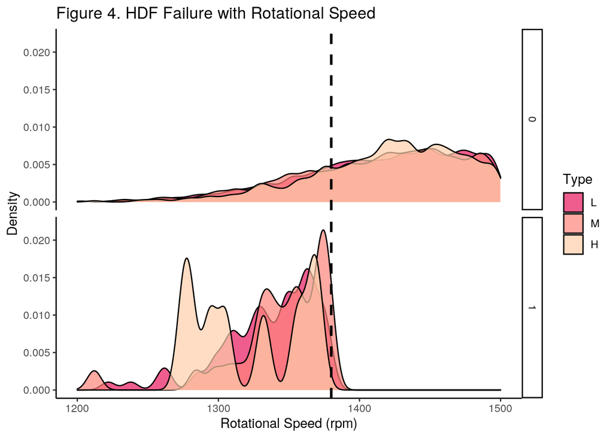

```r
data_clean %>% ggplot(aes(x=Rotational.speed..rpm., fill=Type)) + geom_density(alpha=0.7, bw=5) + facet_grid(rows = vars(HDF)) + xlim(1200, 1500) + ylim(0, 0.022) + xlab('Rotational Speed (rpm)') + ylab('Density') + geom_vline(xintercept=1380, size=1, color="black", linetype = "dashed") + theme_classic() +  scale_fill_manual(values = c("#E8175D", "#FF847C", '#FECEAB')) + ggtitle('Figure 4. HDF Failure with Rotational Speed')
```

Hypothesis 4 We wanted to determine if the rotational speed and temperature difference (proc. temp. - air temp.) should decrease if an HDF failure is present.

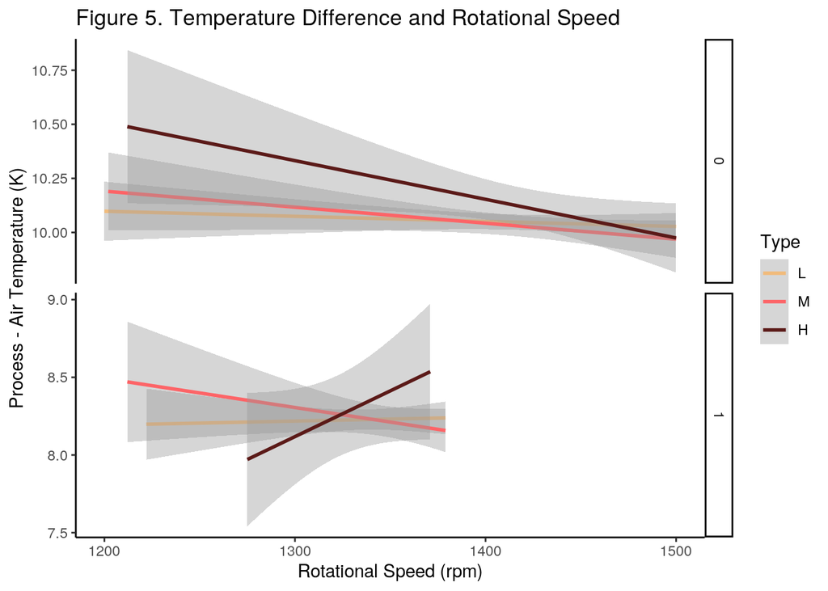

```r
data_clean %>% ggplot(aes(x=Rotational.speed..rpm., y=Diff.temp..K., color=Type)) +
  facet_grid(rows = vars(HDF), scales = "free") +
  geom_smooth(method='lm') +
  xlim(1200, 1500) +
  xlab('Rotational Speed (rpm)') +
  ylab('Process - Air Temperature (K)') +
  theme_classic() +
  scale_color_manual(values = wes_palette("GrandBudapest1", n = 3)) +
  scale_fill_manual(values = wes_palette("GrandBudapest1", n = 3)) +
  ggtitle('Figure 5. Temperature Difference and Rotational Speed')
```

Hypothesis 5 We wanted to determine which features would have a higher correlation. Our hypothesis was that some features of the production process are strongly correlated.

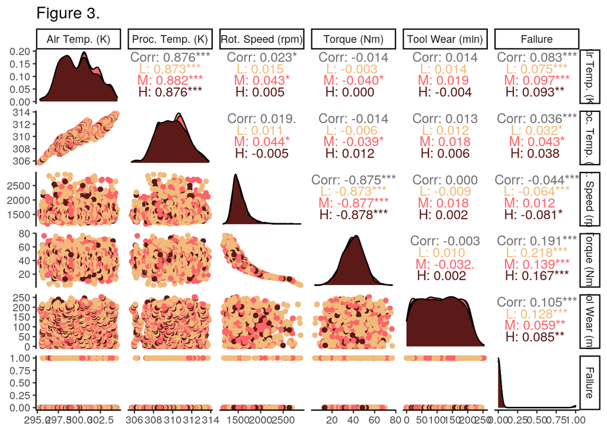

```r
data_clean_features <- data_clean %>% select(-TWF, -HDF, -PWF, -OSF, -RNF, -Diff.temp..K., -NumFails)
data_clean_features <- setNames(data_clean_features, c('Type', 'Air Temp. (K)', 'Proc. Temp. (K)', 'Rot. Speed (rpm)', 'Torque (Nm)', 'Tool Wear (min)', 'Failure'))

# Check correlations (as scatterplots), distribution and print corrleation coefficient
ggpairs(data_clean_features, columns = 2:7, ggplot2::aes(colour=Type)) + theme_classic() + scale_colour_manual(values = wes_palette("GrandBudapest1", n = 3)) +  scale_fill_manual(values = wes_palette("GrandBudapest1", n = 3)) + ggtitle('Figure 3. ')
```

Hypothesis 6 We hypothesized that the distribution of feature values differ depending whether or not we find machine failure.

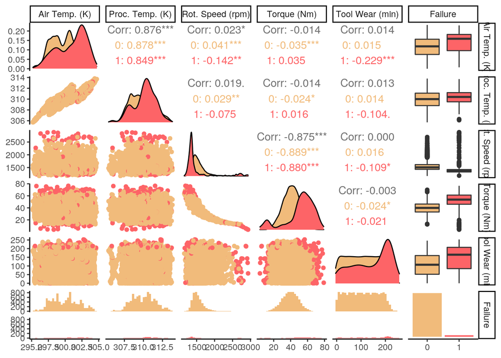

```r
# Create data
data_clean_features <- data_clean %>% select(-TWF, -HDF, -PWF, -OSF, -RNF, -Diff.temp..K., -NumFails)
data_clean_features <- setNames(data_clean_features, c('Type', 'Air Temp. (K)', 'Proc. Temp. (K)', 'Rot. Speed (rpm)', 'Torque (Nm)', 'Tool Wear (min)', 'Failure'))
data_clean_features$Failure<-as.factor(data_clean_features$Failure)

# Check correlations (as scatterplots), distribution and print corrleation coefficient
ggpairs(data_clean_features, columns = 2:7, ggplot2::aes(colour=Failure)) + theme_classic() + scale_colour_manual(values = wes_palette("GrandBudapest1", n = 2)) +  scale_fill_manual(values = wes_palette("GrandBudapest1", n = 2))
```